# Test Questions Practice exam

Michiel Noback

01 November, 2021

## Load the data

You are going to analyse a dataset that describes some properties of a variety of food constituents. In the column header, `carb` stands for carbohydrate, `fat.sat` for saturated fats, and `fat.unsat` for unsaturated fats.

By running the chunk below, load the data.

```r
##KEEPIT##
foods_file <- "https://raw.githubusercontent.com/MichielNoback/intro_R_lessons/gh-pages/data/food_constituents.txt"
foods <- read.table(foods_file, header = TRUE)
head(foods)
```

|  | id.nr | Type | kcal | protein | carb.total | carb.sugar | carb.other | fat.total | fat.sat | fat.unsat | fiber | Na |
| --- | --- | --- | --- | --- | --- | --- | --- | --- | --- | --- | --- | --- |
| 1 | 2 | chocolate | 442 | 5.0 | 67.4 | 64.6 | 2.8 | 15.5 | 9.0 | 6.5 | 6.6 | 0.10 |
| 2 | 3 | chocolate | 433 | 4.9 | 67.9 | 64.9 | 3.0 | 15.5 | 8.9 | 6.6 | 6.8 | 0.18 |
| 3 | 4 | jam | 126 | 0.5 | 30.0 | 30.0 | 0.0 | 0.2 | 0.0 | 0.2 | 0.7 | 0.10 |
| 4 | 5 | jam | 260 | 0.0 | 64.0 | 62.0 | 2.0 | 0.0 | 0.0 | 0.0 | 0.8 | 0.01 |
| 5 | 6 | jam | 244 | 0.6 | 61.0 | 61.0 | 0.0 | 0.1 | 0.1 | 0.0 | 3.1 | 0.01 |
| 6 | 11 | bread | 430 | 12.0 | 76.0 | 4.5 | 71.5 | 7.5 | 3.5 | 4.0 | 3.0 | 0.36 |

## Analyse!

Solve the assignments by filling in your solutions where it says **`##YOUR CODE HERE`** When you’re done, Knit the document into Word and submit that with the rest of your test results.

**Question R-1 (2 points)**

Show the data from columns one, five and six, rows 8-11.

```r
foods[8:11, c(1, 5, 6)]
```

|  | id.nr | carb.total | carb.sugar |
| --- | --- | --- | --- |
| 8 | 19 | 49.0 | 45.4 |
| 9 | 22 | 52.8 | 28.4 |
| 10 | 30 | 78.0 | 0.5 |
| 11 | 31 | 77.0 | 0.0 |

**Question R-2 (2 points)**

Show the Type, kcal and total fat for the food with the highest total fat content.

```r
foods[foods$fat.total == max(foods$fat.total), c(2, 3, 8)]
```

|  | Type | kcal | fat.total |
| --- | --- | --- | --- |
| 137 | nuts | 629 | 51 |

**Question R-3 (4 points)**

Given the dataframes in the chunk below, study the documentation of the `merge()` function. Next, merge the two dataframes without any data loss.

```r
##KEEPIT##
students1 <- data.frame(
    name = c("Mark", "Emily", "John"),
    biology = c(4.5, 6.2, 8.1),
    chemistry = c(6.1, 7.2, 9.3)
)
students2 <- data.frame(
    first_name = c("Emily", "John", "Peter"),
    statistics = c(3.8, 6.6, 6.8)
)
students1
```

| name | biology | chemistry |
| --- | --- | --- |
| Mark | 4.5 | 6.1 |
| Emily | 6.2 | 7.2 |
| John | 8.1 | 9.3 |

```r
students2
```

| first_name | statistics |
| --- | --- |
| Emily | 3.8 |
| John | 6.6 |
| Peter | 6.8 |

```r
merge(students1, students2, by.x = "name", by.y = "first_name", all = TRUE)
```

| name | biology | chemistry | statistics |
| --- | --- | --- | --- |
| Emily | 6.2 | 7.2 | 3.8 |
| John | 8.1 | 9.3 | 6.6 |
| Mark | 4.5 | 6.1 | NA |
| Peter | NA | NA | 6.8 |

**Question R-4 (4 points)**

Create a scatterplot showing the relationship between `kcal` and `carb.total`. Make sure you have correct axis labels. Think about which one you put on the x-axis!

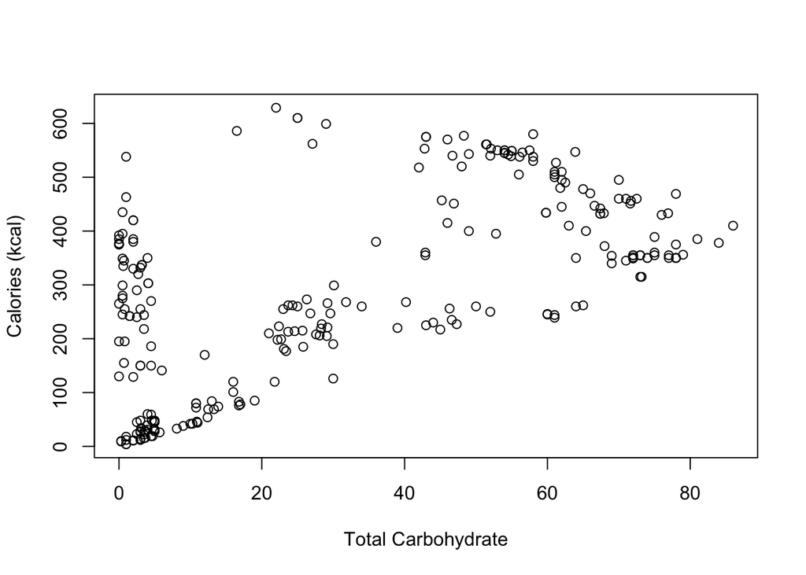

```r
#We do not know the units so they are left out
plot(foods$carb.total, foods$kcal, xlab="Total Carbohydrate", ylab = "Calories (kcal)")
```